# GAE10: PCA & NMDS

Author

Wyatt Stephenson

## Scenario 1: Ecology, Behavior, and Coraciiformes Color

Coraciiform species (Figure 1) have diverse plumage coloration including pigmentary and structural colors, live in a range of different environments, show variable levels of territoriality, variability in the presence or absence of cooperative breeding (but with near uniform social monogamy), and different types of hunting strategy. Babarović et al. (2023) measured plumage coloration from digital images of museum specimens and quantified several proxies for factors that could play a key role in the evolution of coloration including sex, body size, hunting strategy, habitat light environment, territoriality, and social mating system. They were interested in exploring how different possible biotic and abiotic factors may have affected the evolution of Coraciiform coloration.

### Methods:

The researchers used study skins of 117 species of Coraciiformes (families Meropidae, Brachypteraciidae, Coraciidae, Todidae, Momotidae, Alcedinidae) from the bird collections of the Natural History Museum at Tring, UK. Calibrated digital images of study skins were taken using methods described in Cooney et al. (2019) and were used to quantify both chromatic (hue and saturation) and achromatic (brightness) components of color for each of several body regions (patches). The selected body regions were: crown, nape, mantle, rump, tail, wing coverts, wing primaries and secondaries, throat, breast, belly, and tail underside. They then used mapping functions to convert red-green-blue values for each patch on each specimen into values appropriate for the visual abilities of this order. Then they calculated average patch values (separately for each sex) as a species-level measure for each body patch. They then used principle components analysis to reduce the dimensionality of the color data across body patches and species and found that the first principle component accounted for >80% of the variation in color (Babarović et al. 2023). Babarović et al. (2023) then collated information on: body size; light-level associated habitat preference; hunting strategies; territoriality; and cooperative breeding from available literature.

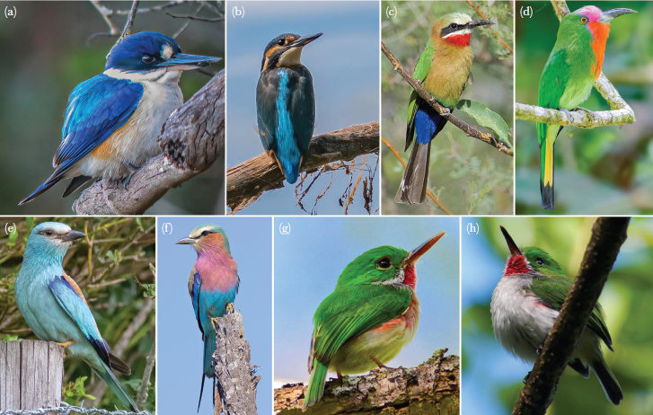

Figure 1: A collage showing some of the plumage color diversity in the Coraciiformes. (a) Forest kingfisher (*Todiramphus macleayii*), Alcedinidae; (b) Common kingfisher (*Alcedo atthis*), Alcedinidae; (c) White-fronted bee-eater (*Merops bullockoides*), Meropidae; (d) Red-bearded bee-eater (*Nyctyornis amictus*), Meropidae; (e) European roller (*Coracias garrulus*), Coraciidae; (f) Lilac-breasted roller (*Coracias caudatus*), Coraciidae; (g) Broad-billed today (*Todus subulatus*), Todidae; (h) Narrow-billed today (*Todus angustirostris*), Todidae. All photos © Daniel J. Field, University of Cambridge.

#### Statistical Methods:

A principal component analysis were run using the FactoMineR package (Lê et al. 2008) using the size, light environment, parental care, territoriality, and hunting strategy variables as supplementary variables. The PCA was then plotted twice the first being a plot of just the variables and the second being a plot of individuals based on hunting strategy using the factoextra package (Kassambara and Mundt 2020).

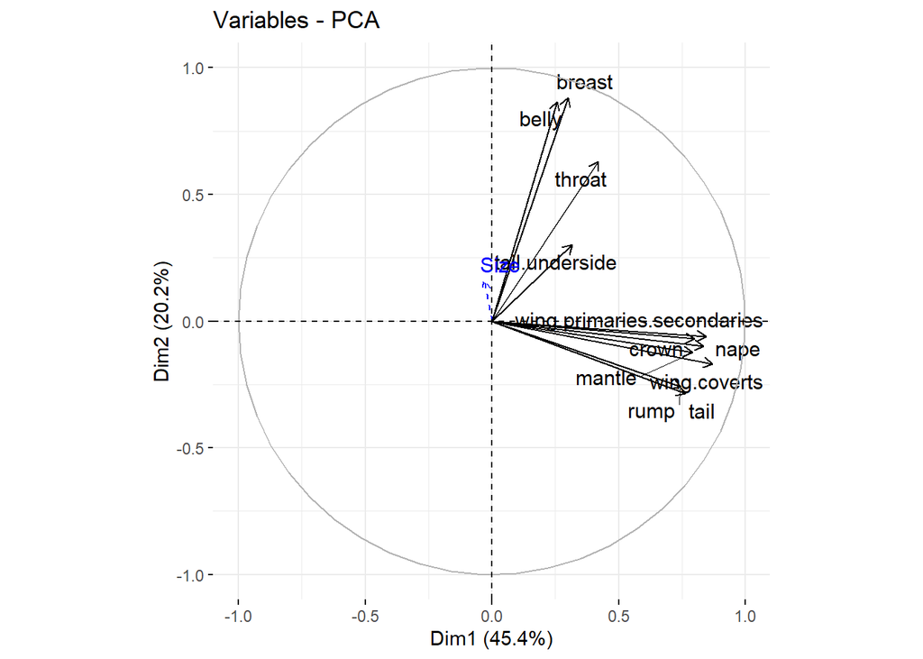

Figure 2: Principal component analysis of anatomical sections

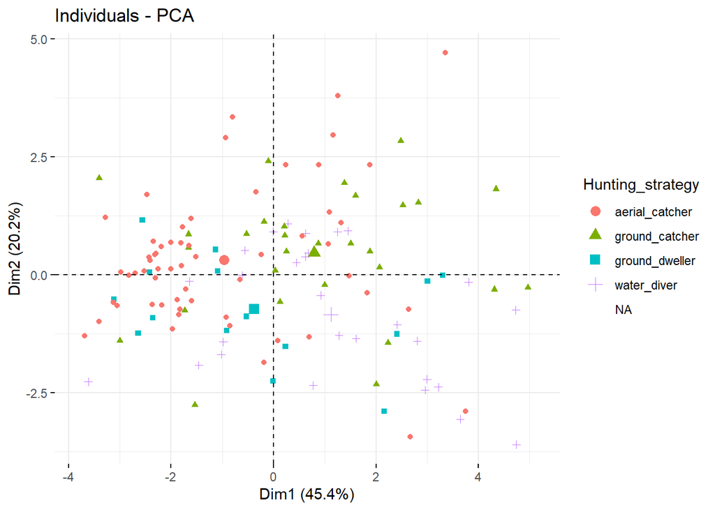

Figure 3: Principle component analysis of species based on hunting strategy

### Results

When looking at the results of our PCA’s we see some clustering in our variables but none within our individuals. Looking first at the PCA of the variables we can see that the anatomical areas found on the dorsal side of the species are positively correlated to dimension 1 which means that these areas tended to be more red and green while the ventral areas of the body are correlated to dimension 2 which means that they tend to be more blue and ultraviolet Figure 2. The reason we might see these trends is that the dorsal areas being more red and green allows for better camouflage when resting in trees along with the ventral side being more blue providing camouflage when in the air. Next looking at the PCA of individuals one was run for all four environmental and behavioral variables but the only on that had any level of clustering was the one based on the hunting strategy of the species. Even with the hunting strategy PCA having some level of clustering there is vary little that can be gained from this clustering due to how spread out and overlapping the groups Figure 3.

## Scenario 2: Deer and Forest Plant Communities

White-tailed deer (*Odocoileus virginianus*) are often considered to be keystone species in forest communities. Sabo et al. (2017) conducted surveys of the vegetation and environmental conditions of deer exclusion plots and adjacent plots outside the exclusion areas as part of a larger study to examine the indirect effects of their presence on the plant assemblages.

### Methods:

In Summer 2011, the researchers visited 17 deer exclosures in upland forests of northern Wisconsin and Michigan’s Upper Peninsula (UP) that were constructed for various previous studies between 1991 and 2002. In each stand, they sampled vegetation and measured key environmental variables inside the fences and in paired ‘deer-access’ plots outside the fences. The latter were in close proximity to the exclosures (always within 100 m), and were placed in locations with similar management histories and overstory structure and composition. Within each exclosure and control area, multiple quadrats were sampled and they recorded the incidence of all herbaceous, shrub, and tree seedling species.

#### Statistical Methods:

First non-dimensional scaling was applied to the data set with fore dimensions using the vegan package(Oksanen et al. 2022a). Then a PermANOVA was run comparing plant communities based on treatment type using the vegan package (Oksanen et al. 2022b) and a table of the results was created using the kableExtra package (Zhu 2021).

```r
Deermds <- metaMDS(
  Deer[,-c(1:2)],
  k=4
)
Deermds$stress
```

[output not shown]

Table 1: PermAnova to test the affect of deer presence on plant communittes

|  | df | SS | $R^2$ | F | p |
| --- | --- | --- | --- | --- | --- |
| Treatment | 1 | 0.115 | 0.011 | 0.343 | 0.988 |
| Residual | 32 | 10.714 | 0.989 |  |  |
| Total | 33 | 10.829 | 1.000 |  |  |

## References:

Babarović, F., C. R. Cooney, Z. K. Varley, L. O. Nouri, N. J. Nadeau, and G. H. Thomas. 2023. [The effects of ecology and behavior on the evolution of coloration in Coraciiformes](https://doi.org/10.1093/beheco/arad008). Behavioral Ecology 34:387–398.

Cooney, C. R., Z. K. Varley, L. O. Nouri, C. J. A. Moody, M. D. Jardine, and G. H. Thomas. 2019. [Sexual selection predicts the rate and direction of colour divergence in a large avian radiation](https://doi.org/10.1038/s41467-019-09859-7). Nature Communications 10:1773.

Kassambara, A., and F. Mundt. 2020. [Factoextra: Extract and visualize the results of multivariate data analyses](https://CRAN.R-project.org/package=factoextra).

Lê, S., J. Josse, and F. Husson. 2008. [FactoMineR: A package for multivariate analysis](https://doi.org/10.18637/jss.v025.i01). Journal of Statistical Software 25:1–18.

Oksanen, J., G. L. Simpson, F. G. Blanchet, R. Kindt, P. Legendre, P. R. Minchin, R. B. O’Hara, P. Solymos, M. H. H. Stevens, E. Szoecs, H. Wagner, M. Barbour, M. Bedward, B. Bolker, D. Borcard, G. Carvalho, M. Chirico, M. De Caceres, S. Durand, H. B. A. Evangelista, R. FitzJohn, M. Friendly, B. Furneaux, G. Hannigan, M. O. Hill, L. Lahti, D. McGlinn, M.-H. Ouellette, E. Ribeiro Cunha, T. Smith, A. Stier, C. J. F. Ter Braak, and J. Weedon. 2022a. [Vegan: Community ecology package](https://CRAN.R-project.org/package=vegan).

Oksanen, J., G. L. Simpson, F. G. Blanchet, R. Kindt, P. Legendre, P. R. Minchin, R. B. O’Hara, P. Solymos, M. H. H. Stevens, E. Szoecs, H. Wagner, M. Barbour, M. Bedward, B. Bolker, D. Borcard, G. Carvalho, M. Chirico, M. De Caceres, S. Durand, H. B. A. Evangelista, R. FitzJohn, M. Friendly, B. Furneaux, G. Hannigan, M. O. Hill, L. Lahti, D. McGlinn, M.-H. Ouellette, E. Ribeiro Cunha, T. Smith, A. Stier, C. J. F. Ter Braak, and J. Weedon. 2022b. [Vegan: Community ecology package](https://CRAN.R-project.org/package=vegan).

Sabo, A. E., K. L. Frerker, D. M. Waller, and E. L. Kruger. 2017. [Deer-mediated changes in environment compound the direct impacts of herbivory on understorey plant communities](https://doi.org/10.1111/1365-2745.12748). Journal of Ecology 105:1386–1398.

Zhu, H. 2021. [kableExtra: Construct complex table with ’kable’ and pipe syntax](https://CRAN.R-project.org/package=kableExtra).